# [PGM3] Analyse d’une enquête sur les pays attractifs et répulsifs

### 2.3 Synthèse

Ce que montrent bien les analyses précédentes est le fait que l’appréciation que les étudiants donnent d’un pays doit être envisagé selon deux dimensions complémentaires, la saillance et l’opinion

- **la saillance** (en anglais *salience*) est le fait qu’un pays se présente à l’esprit d’un étudiant lorsqu’on lui demande de porter un jugement. Peu importe que le jugement soit positif ou négatif, si un pays est cité par l’étudiant c’est qu’il possède des informations sur lui, qu’il en a reçu et a choisi de les retenir. Bref, la saillance manifeste une reconnaissance de l’existence d’un pays et signale sa présence dans la carte mentale de la personne. On la définira donc comme le % des étudiants qui ont cité un pays positivement ou négativement et on la mesurera sur une échelle de 0 à 100

$Saillance_i = 100\times \frac{Pos_i + Neg_i}{n}$

$Polarisation_i = \frac{Pos_i-Neg_i}{Pos_i+Neg_i}$

On ne retient que les pays ayant été cités par au moins 10% des étudiants

```r
nbetud<-length(unique(tabfin$pseudo))
synt <- tabfin %>% filter(is.na(ISO3)==F) %>%
                     group_by(ISO3,name,opi) %>%
                      count() %>%
                      pivot_wider(names_from = opi,
                                  values_from = n,
                                  values_fill = 0) %>%
                       mutate(tot=att+rep,
                              saillance = 100*tot/nbetud,
                              polarisation=(att-rep)/(att+rep)) %>%
                      arrange(-saillance) %>%
                      filter(saillance>=10)

kable(synt, digits=c(0,0,0,0,0,1,2), caption="Saillance et polarisation des pays")
```

Saillance et polarisation des pays

| ISO3 | name | rep | att | tot | saillance | polarisation |
| --- | --- | --- | --- | --- | --- | --- |
| CAN | Canada | 0 | 7 | 7 | 70 | 1.00 |
| FRA | France | 0 | 7 | 7 | 70 | 1.00 |
| AFG | Afghanistan | 6 | 0 | 6 | 60 | -1.00 |
| USA | U.S.A. | 4 | 1 | 5 | 50 | -0.60 |
| GBR | United Kingdom | 0 | 4 | 4 | 40 | 1.00 |
| ISR | Israel | 4 | 0 | 4 | 40 | -1.00 |
| JPN | Japan | 0 | 4 | 4 | 40 | 1.00 |
| SAU | Saudi Arabia | 4 | 0 | 4 | 40 | -1.00 |
| CHE | Switzerland | 0 | 3 | 3 | 30 | 1.00 |
| CHN | China | 2 | 1 | 3 | 30 | -0.33 |
| IRN | Iran | 3 | 0 | 3 | 30 | -1.00 |
| ITA | Italy | 0 | 3 | 3 | 30 | 1.00 |
| AUS | Australia | 0 | 2 | 2 | 20 | 1.00 |
| BEL | Belgium | 0 | 2 | 2 | 20 | 1.00 |
| BLR | Belarus | 2 | 0 | 2 | 20 | -1.00 |
| DEU | Germany | 0 | 2 | 2 | 20 | 1.00 |
| ESP | Spain | 0 | 2 | 2 | 20 | 1.00 |
| NLD | Netherlands | 0 | 2 | 2 | 20 | 1.00 |
| RUS | Russia | 2 | 0 | 2 | 20 | -1.00 |
| SDN | Sudan | 2 | 0 | 2 | 20 | -1.00 |
| YEM | Yemen | 2 | 0 | 2 | 20 | -1.00 |
| AGO | Angola | 1 | 0 | 1 | 10 | -1.00 |
| ARG | Argentina | 1 | 0 | 1 | 10 | -1.00 |
| COG | Congo | 1 | 0 | 1 | 10 | -1.00 |
| CUB | Cuba | 0 | 1 | 1 | 10 | 1.00 |
| DZA | Algeria | 1 | 0 | 1 | 10 | -1.00 |
| GRC | Greece | 0 | 1 | 1 | 10 | 1.00 |
| HND | Honduras | 1 | 0 | 1 | 10 | -1.00 |
| HRV | Croatia | 0 | 1 | 1 | 10 | 1.00 |
| IND | India | 1 | 0 | 1 | 10 | -1.00 |
| IRQ | Iraq | 1 | 0 | 1 | 10 | -1.00 |
| MAR | Morocco | 1 | 0 | 1 | 10 | -1.00 |
| MCO | Monaco | 0 | 1 | 1 | 10 | 1.00 |
| MUS | Mauritius | 0 | 1 | 1 | 10 | 1.00 |
| NGA | Nigeria | 1 | 0 | 1 | 10 | -1.00 |
| NPL | Nepal | 1 | 0 | 1 | 10 | -1.00 |
| PRK | North Korea | 1 | 0 | 1 | 10 | -1.00 |
| PRT | Portugal | 0 | 1 | 1 | 10 | 1.00 |
| PRY | Paraguay | 1 | 0 | 1 | 10 | -1.00 |
| PSE | Palestine | 1 | 0 | 1 | 10 | -1.00 |
| SLV | El Salvador | 1 | 0 | 1 | 10 | -1.00 |
| SSD | South Sudan | 1 | 0 | 1 | 10 | -1.00 |
| SWE | Sweden | 0 | 1 | 1 | 10 | 1.00 |
| SYR | Syria | 1 | 0 | 1 | 10 | -1.00 |
| TCD | Chad | 1 | 0 | 1 | 10 | -1.00 |
| TWN | Taiwan | 0 | 1 | 1 | 10 | 1.00 |
| UKR | Ukraine | 1 | 0 | 1 | 10 | -1.00 |
| VAT | Vatican | 0 | 1 | 1 | 10 | 1.00 |
| ZWE | Zimbabwe | 1 | 0 | 1 | 10 | -1.00 |

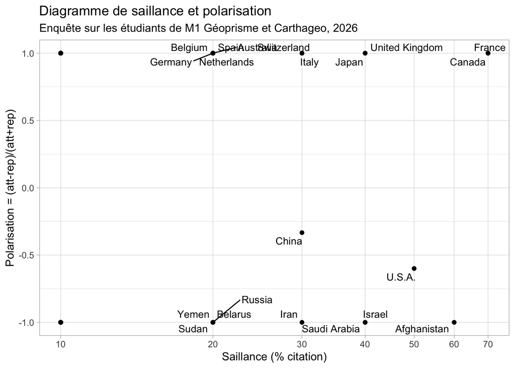

```r
ggplot(synt, aes(x=saillance, y = polarisation)) +
        geom_point() +
        geom_text_repel(aes(label = name),cex=3.5)+
        scale_x_log10("Saillance (% citation)",
                      breaks=c(10,20,30,40,50,60,70),
                      minor_breaks=NULL,
                      lim =c(10,70))+
  scale_y_continuous("Polarisation = (att-rep)/(att+rep)")+
        ggtitle(label = "Diagramme de saillance et polarisation" ,
                subtitle = "Enquête sur les étudiants de M1 Géoprisme et Carthageo, 2026") +
         theme_light()
```

## 3 (C) ANALYSE DE GRAPHE (non orienté)

Nous avons vu précédemment les pays les plus cités positivement ou négativement. Mais nous ignorons s’il existe des **associations préférentielles de pays dans les réponses**. Par exemple, les étudiants qui aimeraient vivre en Italie sont-ils également ceux qui souhaiteraient vivre en Espagne ? Ou bien les étudiants qui n’aimeraient pas vivre en Russie sont-ils les mêmes que ceux qui n’aimeraient pas vivre aux USA ? etc.

Pour répondre à ces questions, nous devons construire un nouveau tableau permettant de définir des choix conjoints de pays puis transformer ceci en graphe. Cdela suppose de passer par un travail mathématique sur des objets de type **matrice**.

## 4 Associations de pays Répulsifs

### 4.1 Matrice étudiants x pays

```r
tab<- readRDS("data_network/attrep.RDS")

# Repérage des pays cités positivement trois fois ou plus
sel <- tab %>% filter(opi=="rep") %>%
               group_by(ISO3) %>%
               count() %>%
               filter(n>2, is.na(ISO3)==F) %>%
               select(ISO3)

# Sélection des réponses
rep <- tab %>% filter(opi=="rep",
                      ISO3 %in% sel$ISO3) %>%
              mutate(OK=1)%>%
               select(pseudo,ISO3,OK)


# Passage en matrice
mat <- as.matrix(table(rep$pseudo, rep$ISO3))

kable(mat,caption = "Matrice des réponses négatives")
```

Matrice des réponses négatives

|  | AFG | IRN | ISR | SAU | USA |
| --- | --- | --- | --- | --- | --- |
| AAA | 0 | 1 | 0 | 1 | 0 |
| COME | 1 | 0 | 0 | 0 | 0 |
| COUCOU | 1 | 0 | 1 | 0 | 1 |
| ENEXTO | 1 | 0 | 1 | 0 | 0 |
| LDLD05 | 0 | 0 | 0 | 1 | 1 |
| LUCSPY | 0 | 1 | 1 | 0 | 0 |
| R | 1 | 0 | 1 | 1 | 1 |
| SIMCA | 1 | 1 | 0 | 0 | 0 |
| YUTYUT | 1 | 0 | 0 | 1 | 1 |

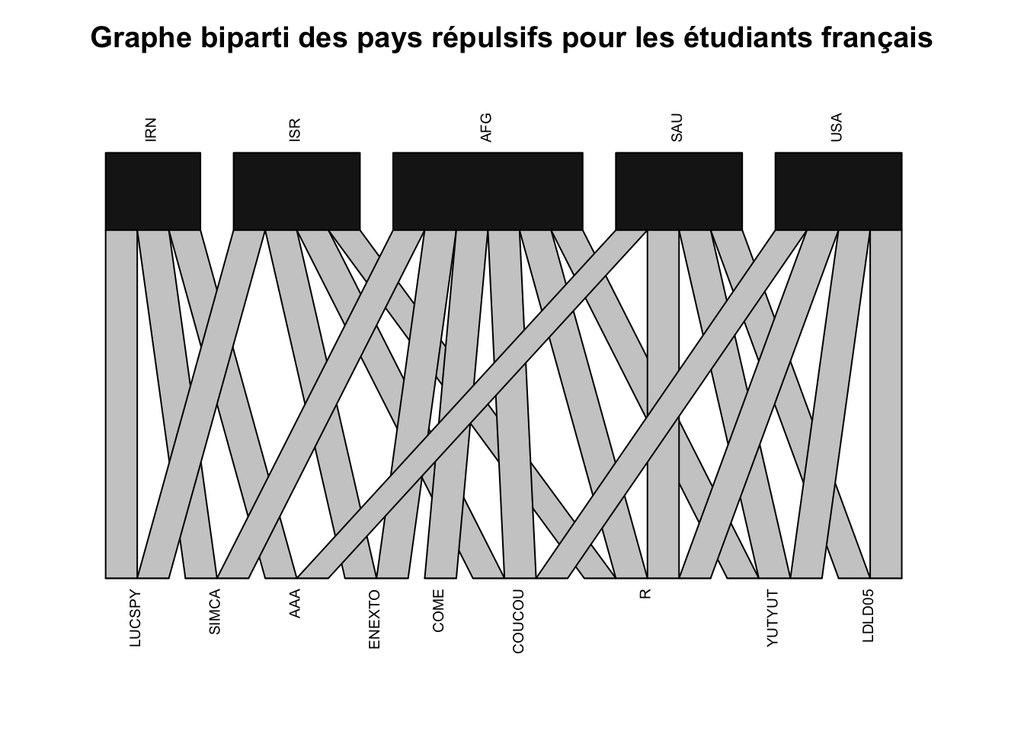

```r
library(bipartite)
colsum<-apply(mat,2,sum)


plotweb_deprecated(mat,
                   low.lablength = 10,
                   y.width.low = 0,
                   text.rot = 90)

title("Graphe biparti des pays répulsifs pour les étudiants français")
```

### 4.2 Matrice étudiant x étudiant

```r
mat_etu <- mat %*% t(mat)
diag(mat_etu)<-NA
kable(mat_etu)
```

|  | AAA | COME | COUCOU | ENEXTO | LDLD05 | LUCSPY | R | SIMCA | YUTYUT |
| --- | --- | --- | --- | --- | --- | --- | --- | --- | --- |
| AAA | NA | 0 | 0 | 0 | 1 | 1 | 1 | 1 | 1 |
| COME | 0 | NA | 1 | 1 | 0 | 0 | 1 | 1 | 1 |
| COUCOU | 0 | 1 | NA | 2 | 1 | 1 | 3 | 1 | 2 |
| ENEXTO | 0 | 1 | 2 | NA | 0 | 1 | 2 | 1 | 1 |
| LDLD05 | 1 | 0 | 1 | 0 | NA | 0 | 2 | 0 | 2 |
| LUCSPY | 1 | 0 | 1 | 1 | 0 | NA | 1 | 1 | 0 |
| R | 1 | 1 | 3 | 2 | 2 | 1 | NA | 1 | 3 |
| SIMCA | 1 | 1 | 1 | 1 | 0 | 1 | 1 | NA | 1 |
| YUTYUT | 1 | 1 | 2 | 1 | 2 | 0 | 3 | 1 | NA |

```r
mat2<-mat_etu

#mat3[mat3>2]<-1
net<-graph_from_adjacency_matrix(mat2,mode = "undirected",weighted = T,diag = F)
net2<-visIgraph(net)
nod<-net2$x$nodes
edg<-net2$x$edges

visNetwork(nod, edg)
```

[interactive chart not shown]

### 4.3 Matrice pays x pays

On utilise la même astuce mathématique

```r
mat_pays <- t(mat) %*% mat
diag(mat_pays)<-NA
kable(mat_pays)
```

|  | AFG | IRN | ISR | SAU | USA |
| --- | --- | --- | --- | --- | --- |
| AFG | NA | 1 | 3 | 2 | 3 |
| IRN | 1 | NA | 1 | 1 | 0 |
| ISR | 3 | 1 | NA | 1 | 2 |
| SAU | 2 | 1 | 1 | NA | 3 |
| USA | 3 | 0 | 2 | 3 | NA |

```r
library(visNetwork)
library(igraph)
mat3<-mat_pays
mat3[mat3<2]<-0
mat3
```

```
      AFG IRN ISR SAU USA
  AFG  NA   0   3   2   3
  IRN   0  NA   0   0   0
  ISR   3   0  NA   0   2
  SAU   2   0   0  NA   3
  USA   3   0   2   3  NA
```

```r
#mat3[mat3>2]<-1
net<-graph_from_adjacency_matrix(mat3,mode = "undirected",weighted = T,diag = F)
net2<-visIgraph(net)
nod<-net2$x$nodes
edg<-net2$x$edges

visNetwork(nod, edg)
```

[interactive chart not shown]